# Analysis of health and economic problems casued by weather

lingas

Saturday, May 23, 2015

# Synopsis

Storms and other severe weather events can cause both public health and economic problems for communities and municipalities. Many severe events can result in fatalities, injuries, and property damage, and preventing such outcomes to the extent possible is a key concern.

This report analyse and shows e event that have the most harmful with respect to population health and e event that causes the greatest economic consequences.

# Overview

This report uses the data source provided by NOAA.

The raw data is then subsetted to 2 part which part only contains the data required for the analysis.

1. Types of events are most harmful with respect to population health
2. Types of events have the greatest economic consequences

**Data Processing** section show the subsetting process.

**Result** section show a graphical view on the analysed data.

# Dependencies

```r
library(knitr)

# Global Settings
opts_chunk$set(echo = TRUE, results = 'hold', cache=TRUE)
```

# Data Source

[Storm Data : 47Mb](https://d396qusza40orc.cloudfront.net/repdata%2Fdata%2FStormData.csv.bz2)

*Place the downloaded data in the working directory*

```r
#Unzip and read the dataset.
data <- read.csv(bzfile("repdata-data-StormData.csv.bz2"),
                 header = T,
                 na.strings = "",
                 quote="\"",
                 sep = "," ,
                 stringsAsFactors=FALSE)
```

# Data Processing

Subsetting of the data allows the program to run on a smaller dataset as compared to the original raw data.

### Extract data required to find the event type that have the most harmful consequences to population health

```r
effectonhealth = data[,c("EVTYPE", "FATALITIES", "INJURIES")]

injurysum = aggregate(effectonhealth$INJURIES, by=list(effectonhealth$EVTYPE), FUN=sum)

names(injurysum) = c("eventtype","injurycount")

fatalitysum = aggregate(effectonhealth$FATALITIES, by=list(effectonhealth$EVTYPE), FUN=sum)

names(fatalitysum) = c("eventtype","fatalitycount")

healthcost = cbind(injurysum,fatalitysum$fatalitycount)

names(healthcost) = c("eventtype","injurycount", "fatalitycount")

healthcost$cost = healthcost$injurycount + healthcost$fatalitycount
```

### Extract data required to find the event type greatest economic consequences

```r
effectonecon = data[,c("EVTYPE", "PROPDMG", "PROPDMGEXP", "CROPDMG", "CROPDMGEXP")]
```

*PROPDMGEXP* and *CROPDMGEXP* contains the unit of measurement for *PROPDMG* and *CROPDMG* respectively.

Following is the conversion

| Type | Description | Numerical Value |
| --- | --- | --- |
| K , k | Thousands | 10^3 |
| M , m | Millions | 10^6 |
| B , b | Billions | 10^9 |

All other non-numerical values will be treated as zero.

```r
#Subsitute values for numerical representation
effectonecon$PROPDMGEXP = as.character(effectonecon$PROPDMGEXP)
effectonecon$PROPDMGEXP = gsub("\\+|\\?|0|\\-","0",effectonecon$PROPDMGEXP)
effectonecon$PROPDMGEXP = gsub("h", "0", effectonecon$PROPDMGEXP,ignore.case = TRUE)
effectonecon$PROPDMGEXP = gsub("b", "1000000000", effectonecon$PROPDMGEXP,ignore.case = TRUE)
effectonecon$PROPDMGEXP = gsub("m", "1000000", effectonecon$PROPDMGEXP,ignore.case = TRUE)
effectonecon$PROPDMGEXP = gsub("k", "1000", effectonecon$PROPDMGEXP,ignore.case = TRUE)

effectonecon$CROPDMGEXP = as.character(effectonecon$CROPDMGEXP)
effectonecon$CROPDMGEXP = gsub("\\+|\\?|0|\\-","0",effectonecon$CROPDMGEXP)
effectonecon$CROPDMGEXP = gsub("h", "0", effectonecon$CROPDMGEXP,ignore.case = TRUE)
effectonecon$CROPDMGEXP = gsub("b", "1000000000", effectonecon$CROPDMGEXP,ignore.case = TRUE)
effectonecon$CROPDMGEXP = gsub("m", "1000000", effectonecon$CROPDMGEXP,ignore.case = TRUE)
effectonecon$CROPDMGEXP = gsub("k", "1000", effectonecon$CROPDMGEXP,ignore.case = TRUE)

# Convert values to numeric
effectonecon$PROPDMGEXP = as.numeric(effectonecon$PROPDMGEXP)
effectonecon$CROPDMGEXP = as.numeric(effectonecon$CROPDMGEXP)

# Convert NA to 0
effectonecon$CROPDMGEXP[is.na(effectonecon$CROPDMGEXP)] = 0
effectonecon$PROPDMGEXP[is.na(effectonecon$PROPDMGEXP)] = 0

effectonecon$economiccost = effectonecon$PROPDMGEXP * effectonecon$PROPDMG +
                            effectonecon$CROPDMGEXP * effectonecon$CROPDMG

econcost = effectonecon[,c("EVTYPE", "economiccost")]
names(econcost) = c("eventtype","cost")
```

# Result

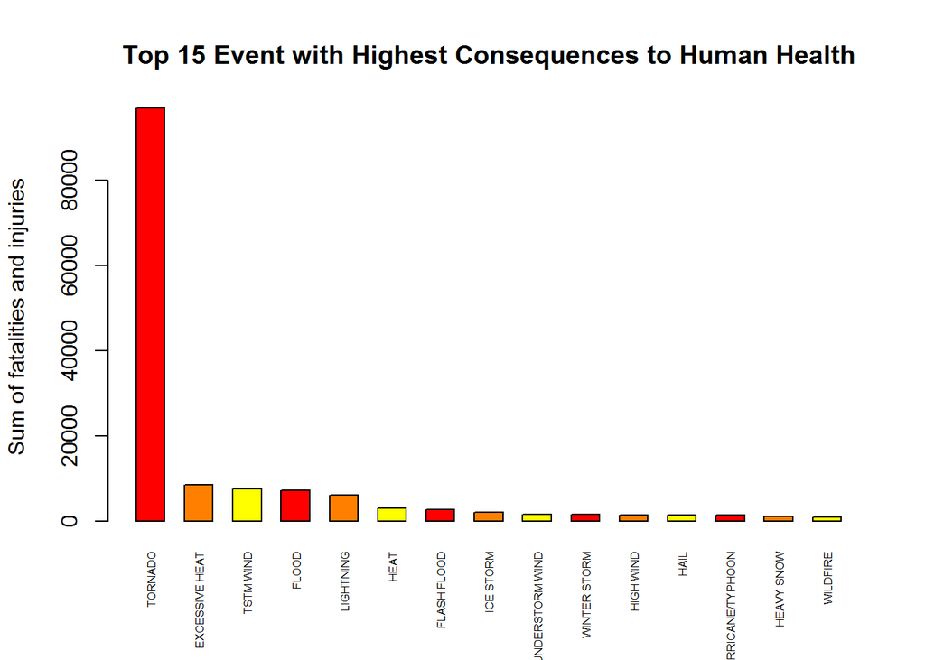

```r
#Plot only the top 15 events which have the highest population health consequences
healthdata = head(healthcost[order(healthcost$cost, decreasing = T), ], 15)

barplot(healthdata$cost,
        main="Top 15 Event with Highest Consequences to Human Health",
        ylab="Sum of fatalities and injuries",
        las=3,
        names.arg=healthdata$eventtype,
        width = 0.5,
        space = 0.7,
        col=heat.colors(3),
        cex.names=0.5)
```

As seen from the graph above , **TORNADO** is the event which result in the highest injury and fataliies to human.

### Analysis of Events with Highest Economic Consequences

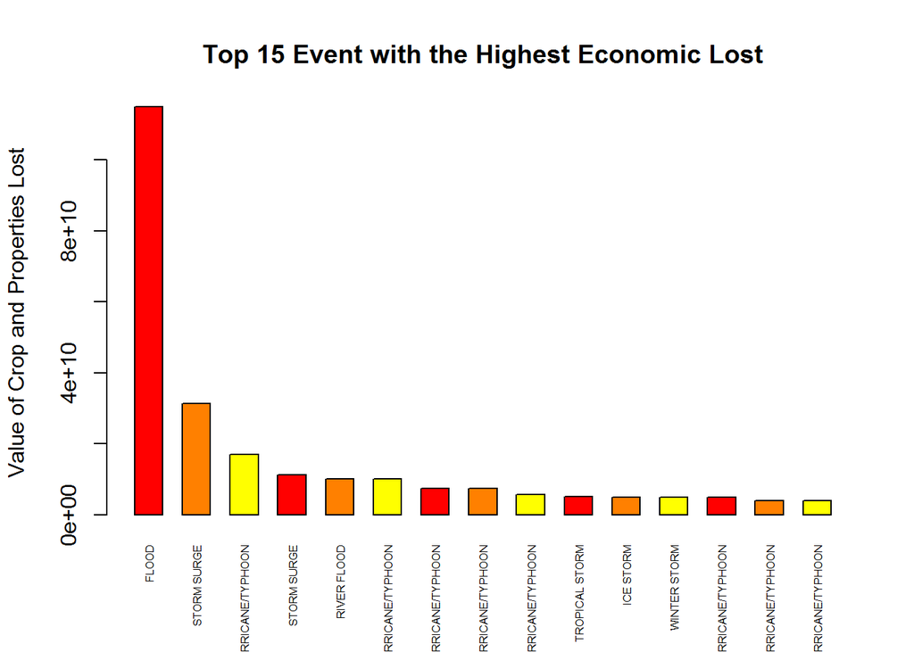

```r
#Plot only the top 15 events with highest enconomic loss
econcost = head(econcost[order(econcost$cost, decreasing = T), ], 15)

barplot(econcost$cost,
        main="Top 15 Event with the Highest Economic Lost",
        ylab="Value of Crop and Properties Lost",
        las=3,
        names.arg=econcost$eventtype,
        width = 0.5,
        space = 0.7,
        col=heat.colors(3),
        cex.names=0.5)
```

This analysis is limited to show only the weather event that have the largest effect of economic losses and the event that have the most effect on population.

Furthur analysis can be performed if a breakdown of economic losses into crop and properties or effect on population into injuries and fatalities. This breakdown is not investigated as part of this report scope.